# Healthcare-Associated Infections, State

Zach Christensen

September 4, 2015

## Executive Summary

The Healthcare-Associated Infections (HAI) measures - state data. These measures are developed by Centers for Disease Control and Prevention (CDC) and collected through the National Healthcare Safety Network (NHSN). They provide information on infections that occur while the patient is in the hospital. These infections can be related to devices, such as central lines and urinary catheters, or spread from patient to patient after contact with an infected person or surface. Many healthcare associated infections can be prevented when the hospitals use CDC-recommended infection control steps.

The metric reported is standardized infection ratios (SIRs). SIRs compare the actual number of Healthcare-Assiocated Infections at each hospital to the predicted number of infections. These ratios are adjusted for various risk factors and population traits. More information about SIRs and how they are calculated can be found here: http://www.leapfroggroup.org/media/file/SIRCalc.pdf. .

## Import Libraries and Data Set

The analysis relies on several open source libraries, and uses data directly from the healthdata.gov API.

```r
# Load Required Libraries
library(dplyr)
library(tidyr)
library(reshape2)
library(ggplot2)
library(googleVis)
op <- options(gvis.plot.tag = "chart")
library(caret)
library(randomForest)
set.seed(2015)


# Abreviations and regions for the 50 states
stateAbrevs <- data.frame(c("IL", "IN", "IA", "KY", "MI", "MN", "MO", "OH", "WI", "CT", "DE", "ME", "MD", "MA", "NH", "NJ", "NY", "PA", "RI", "VT", "AK", "AZ", "CA", "HI", "NV", "OR", "UT", "WA","AL", "AR", "FL", "GA", "LA", "MS", "NC", "SC", "TN", "VA", "WV", "CO", "ID", "KS", "MT", "NE", "NM", "ND", "OK", "SD", "TX", "WY"))
stateRegs <- data.frame(c("central", "central", "central", "central", "central", "central", "central", "central", "central", "northern", "northern", "northern", "northern", "northern", "northern", "northern", "northern", "northern", "northern", "northern", "pacific", "pacific", "pacific", "pacific", "pacific", "pacific", "pacific", "pacific", "southern", "southern", "southern", "southern", "southern", "southern", "southern", "southern", "southern", "southern", "southern", "western", "western", "western", "western", "western", "western", "western", "western", "western", "western", "western"))
regions <- cbind(stateAbrevs, stateRegs)
colnames(regions) <- c("State", "Region")

# Load data from healthdata.gov
states <- read.csv("http://data.medicare.gov/api/views/k2ze-bqvw/rows.csv?accessType=DOWNLOAD")
```

## Preprocessing

The dataset contains 7 measurements: *State, Measure.Name, Measure.ID, Score, Footnote, Measure.Start.Date, Measure.End.Date*. The data was collected from 10/01/2013 to 09/30/2014, with information about different measures collected from 56 states or regions.

```r
# Split the Measure.ID column
states <- states %>% mutate("Measure" = substring(text = Measure.ID, first = 1, last = 5),
                            "Type" = substring(text = Measure.ID, first = 7,
                                               last = length(Measure.ID)))

# List of different measures
measures <- unique(filter(states, Type == "SIR")[,c("Measure", "Measure.Name")])

# Then only select needed columns
states <- subset(states, select = c("State", "Measure.Name", "Measure", "Type", "Score"))
states <- dcast(states, State + Measure ~ Type)

# Join the measures so we get measure names with data
states <- left_join(states, measures)

# Remove rows which have NA
states <- states[-which(is.na(states$SIR)),]

# Create data.frame with just SIRs by state
sirs <- dcast(states, State ~ Measure, value.var = "SIR")

# Reduce the list to only contain the 50 states
sirs <- inner_join(sirs, regions, by = c("State" = "State"))
```

The 6 measures tracked by the dataset are:

```
## [1] Catheter-Associated Urinary Tract Infections (CAUTI)
## [2] Clostridium difficile (C.diff.) Laboratory-identified Events (Intestinal infections)
## [3] Methicillin-resistant Staphylococcus Aureus (MRSA) Blood Laboratory-identified Events (Bloodstream infections)
## [4] Central line-associated blood stream infections (CLABSI)
## [5] Surgical Site Infection from abdominal hysterectomy (SSI: Hysterectomy)
## [6] Surgical Site Infection from colon surgery (SSI: Colon)
## 18 Levels: C.diff Lower Confidence Limit ... Surgical Site Infection from colon surgery (SSI: Colon)
```

The data set is reduced to only contain information for the 50 states, and restructured so each row represents a state, with a column for each measurement and another for the states’ region.

```
##   State HAI_1 HAI_2 HAI_3 HAI_4 HAI_5 HAI_6   Region
## 1    AK 0.526 1.319 0.763 0.849 0.405 0.804  pacific
## 2    AL 0.588 0.926 0.721 0.504 1.144 0.660 southern
## 3    AR 0.510 1.090 0.978 1.079 1.118 0.642 southern
## 4    AZ 0.470 1.213 1.090 1.114 0.992 0.912  pacific
## 5    CA 0.409 1.215 1.044 0.904 0.750 1.053  pacific
## 6    CO 0.438 0.857 0.774 1.005 0.553 1.047  western
```

## Exploration

We can plot the SIR scores for each Measure by State.

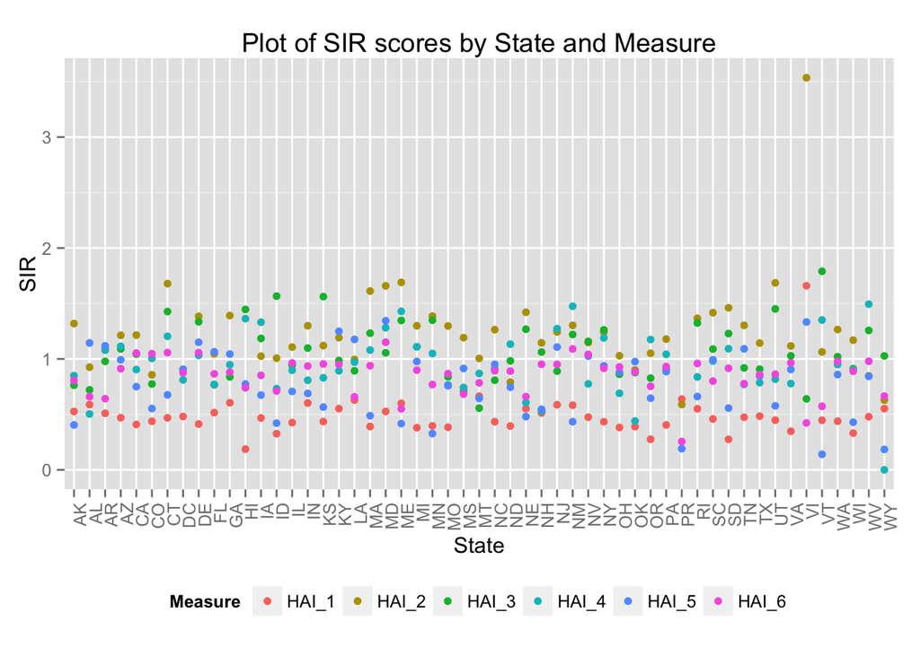

```r
qplot(State, SIR, data = states, col = Measure, main = "Plot of SIR scores by State and Measure") +
  theme(axis.text.x = element_text(angle = 90, hjust = 1), legend.position="bottom")
```

Visually, it looks like the the SIR scores for HAI_2, Catheter-Associated Urinary Tract Infections (CAUTI) are usually the highest, while HAI_1, Central line-associated blood stream infections (CLABSI) are the lowest. Below is the average score and standard deviation grouped by measure, which confirms the visual observation.

```
## Source: local data frame [6 x 3]
##
##   Measure mean(SIR)   sd(SIR)
## 1   HAI_1 0.4933585 0.1942709
## 2   HAI_2 1.2253019 0.4100984
## 3   HAI_3 1.0623462 0.2597521
## 4   HAI_4 0.9484314 0.2809226
## 5   HAI_5 0.7763774 0.2965325
## 6   HAI_6 0.8499434 0.1693796
```

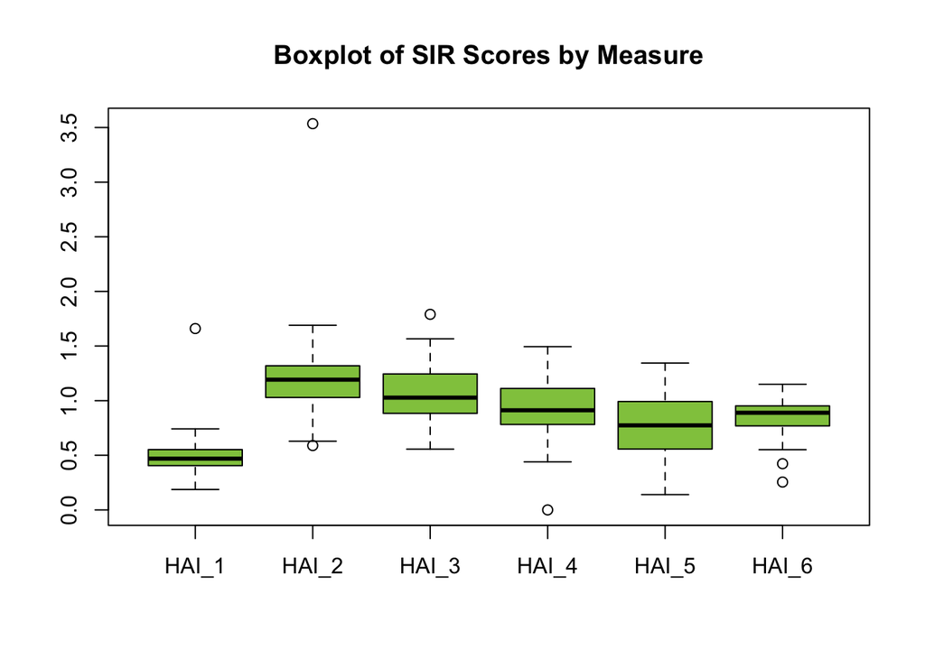

### Confidence Intervals

It should be noted that this analysis only uses the SIR score, ignoring the confidence intervals also included in the data set. This is of less significance for this analysis, but care should be given if this data were being analyzed to evaluate or predict the effectiveness of regulations or procedures on SIR scores. There are 121 measurements which contain 1 in the confidence interval; this means that while the SIR score may be above or below 1, careful consideration should be given before concluding that the measurement respresents a significant improvement or worsening from the expected incident rate.

## Regional Analysis

```r
# Compute and Print Correlations
cor(sirs[,2:7])
```

```
##            HAI_1      HAI_2       HAI_3       HAI_4       HAI_5
## HAI_1  1.0000000 0.12931414 -0.30863708 -0.15110021  0.16954897
## HAI_2  0.1293141 1.00000000  0.25926305  0.26297632  0.01745694
## HAI_3 -0.3086371 0.25926305  1.00000000  0.34107364 -0.41665337
## HAI_4 -0.1511002 0.26297632  0.34107364  1.00000000  0.03881742
## HAI_5  0.1695490 0.01745694 -0.41665337  0.03881742  1.00000000
## HAI_6 -0.1694669 0.21678285 -0.02889971  0.17031538  0.26476307
##             HAI_6
## HAI_1 -0.16946686
## HAI_2  0.21678285
## HAI_3 -0.02889971
## HAI_4  0.17031538
## HAI_5  0.26476307
## HAI_6  1.00000000
```

```r
# Create training and test set
inTrain <- createDataPartition(sirs$Region, p = 0.75, list = FALSE)
train <- sirs[inTrain,]
test <- sirs[-inTrain,]

# Create a random forest model from the train dataset
# Attempt to predict Region based on the 6 Healthcare-Associated Infections
# Using a trainControl to use cross-validation 4 times
rfModel <- train(Region ~ HAI_1 + HAI_2 + HAI_3 + HAI_4 + HAI_5 + HAI_6, train, method = "rf", trControl=trainControl(method = "cv", number = 4))

# Use the model to predict the Region for the test set
rfPredict <- predict(rfModel$finalModel, test, type = "class")

# Compare the predictions to the actual regions
rfMatrix <- confusionMatrix(rfPredict, test$Region)
```

The `predict` method takes the generate model and predicts the Regions for the samples in the test set. `confusionMatrix` then compares the predicted results with the actual results, and computes several statistics about the model. The output of this method contains information used to evaluate the model.

```r
# Print confusion matrix
rfMatrix
```

```
## Confusion Matrix and Statistics
##
##           Reference
## Prediction central northern pacific southern western
##   central        0        0       0        0       0
##   northern       0        1       1        0       0
##   pacific        1        1       0        0       0
##   southern       1        0       0        2       1
##   western        0        0       1        0       1
##
## Overall Statistics
##
##                Accuracy : 0.4
##                  95% CI : (0.1216, 0.7376)
##     No Information Rate : 0.2
##     P-Value [Acc > NIR] : 0.1209
##
##                   Kappa : 0.25
##  Mcnemar's Test P-Value : NA
##
## Statistics by Class:
##
##                      Class: central Class: northern Class: pacific
## Sensitivity                     0.0          0.5000          0.000
## Specificity                     1.0          0.8750          0.750
## Pos Pred Value                  NaN          0.5000          0.000
## Neg Pred Value                  0.8          0.8750          0.750
## Prevalence                      0.2          0.2000          0.200
## Detection Rate                  0.0          0.1000          0.000
## Detection Prevalence            0.0          0.2000          0.200
## Balanced Accuracy               0.5          0.6875          0.375
##                      Class: southern Class: western
## Sensitivity                    1.000         0.5000
## Specificity                    0.750         0.8750
## Pos Pred Value                 0.500         0.5000
## Neg Pred Value                 1.000         0.8750
## Prevalence                     0.200         0.2000
## Detection Rate                 0.200         0.1000
## Detection Prevalence           0.400         0.2000
## Balanced Accuracy              0.875         0.6875
```

The ‘simpliest’ measure of an algorithm’s success is it’s accuracy or error rate (1 - accuracy). The accuracy for the above model is 0.4, giving an error rate of 0.6. Obviously, this error rate is pretty high, which isn’t too surprising. The rates of Healthcare-Associated Infections is likely dependent on more complicated variables than a state’s Region, such as the financial resources dedicated to reducing the rate, or the health and demographics of the state.